# 1 Data Preprocessing

Each predicted keypoint is specified by an (x,y) real-valued pair in the space of pixel indices. There are 15 keypoints, which represent the following elements of the face:

left_eye_center, right_eye_center, left_eye_inner_corner, left_eye_outer_corner, right_eye_inner_corner, right_eye_outer_corner, left_eyebrow_inner_end, left_eyebrow_outer_end, right_eyebrow_inner_end, right_eyebrow_outer_end, nose_tip, mouth_left_corner, mouth_right_corner, mouth_center_top_lip, mouth_center_bottom_lip

Left and right here refers to the point of view of the subject.

In some examples, some of the target keypoint positions are misssing (encoded as missing entries in the csv, i.e., with nothing between two commas).

The input image is given in the last field of the data files, and consists of a list of pixels (ordered by row), as integers in (0,255). The images are 96x96 pixels.

## Preprocessing Data Files:

training.csv: list of training 7049 images. Each row contains the (x,y) coordinates for 15 keypoints, and image data as row-ordered list of pixels. test.csv: list of 1783 test images. Each row contains ImageId and image data as row-ordered list of pixels submissionFileFormat.csv: list of 27124 keypoints to predict. Each row contains a RowId, ImageId, FeatureName, Location. FeatureName are "left_eye_center_x," "right_eyebrow_outer_end_y," etc. Location is what you need to predict.

## 1.1 Import libraries

```python
import numpy as np
import matplotlib.pyplot as plt
import pandas as pd
from IPython.display import clear_output
from time import sleep
import os
```

```python
from keras.models import Sequential
from keras.layers import Conv2D, Activation, Dropout, Dense, Flatten, MaxPooling2D, BatchNormalization
from keras import optimizers
from keras.callbacks import ReduceLROnPlateau, CSVLogger, ModelCheckpoint, EarlyStopping, LearningRateScheduler
```

## 1.2 Import data files

```python
Train_Dir = '/content/drive/My Drive/F19/CS 583 - Deep Learning/Assignments/final-project/data/training.csv'
Test_Dir = '/content/drive/My Drive/F19/CS 583 - Deep Learning/Assignments/final-project/data/test.csv'
lookid_dir = '/content/drive/My Drive/F19/CS 583 - Deep Learning/Assignments/final-project/data/IdLookupTable.csv'
train_data = pd.read_csv(Train_Dir)
test_data = pd.read_csv(Test_Dir)
lookid_data = pd.read_csv(lookid_dir)
os.listdir('/content/drive/My Drive/F19/CS 583 - Deep Learning/Assignments/final-project/data')
```

```
['.~lock.training.csv#',
 'IdLookupTable.csv',
 'SampleSubmission.csv',
 'test.csv',
 'training.csv']
```

## 1.3 Training Data

### 1.3.1 Look at the data

take a look at the data

```python
train_data.head().T
```

|  | 0 | 1 | 2 | 3 | 4 |
| --- | --- | --- | --- | --- | --- |
| left_eye_center_x | 66.0336 | 64.3329 | 65.0571 | 65.2257 | 66.7253 |
| left_eye_center_y | 39.0023 | 34.9701 | 34.9096 | 37.2618 | 39.6213 |
| right_eye_center_x | 30.227 | 29.9493 | 30.9038 | 32.0231 | 32.2448 |
| right_eye_center_y | 36.4217 | 33.4487 | 34.9096 | 37.2618 | 38.042 |
| left_eye_inner_corner_x | 59.5821 | 58.8562 | 59.412 | 60.0033 | 58.5659 |
| left_eye_inner_corner_y | 39.6474 | 35.2743 | 36.321 | 39.1272 | 39.6213 |
| left_eye_outer_corner_x | 73.1303 | 70.7227 | 70.9844 | 72.3147 | 72.5159 |
| left_eye_outer_corner_y | 39.97 | 36.1872 | 36.321 | 38.381 | 39.8845 |
| right_eye_inner_corner_x | 36.3566 | 36.0347 | 37.6781 | 37.6186 | 36.9824 |
| right_eye_inner_corner_y | 37.3894 | 34.3615 | 36.321 | 38.7541 | 39.0949 |
| right_eye_outer_corner_x | 23.4529 | 24.4725 | 24.9764 | 25.3073 | 22.5061 |
| right_eye_outer_corner_y | 37.3894 | 33.1444 | 36.6032 | 38.0079 | 38.3052 |
| left_eyebrow_inner_end_x | 56.9533 | 53.9874 | 55.7425 | 56.4338 | 57.2496 |
| left_eyebrow_inner_end_y | 29.0336 | 28.2759 | 27.5709 | 30.9299 | 30.6722 |
| left_eyebrow_outer_end_x | 80.2271 | 78.6342 | 78.8874 | 77.9103 | 77.7629 |
| left_eyebrow_outer_end_y | 32.2281 | 30.4059 | 32.6516 | 31.6657 | 31.7372 |
| right_eyebrow_inner_end_x | 40.2276 | 42.7289 | 42.1939 | 41.6715 | 38.0354 |
| right_eyebrow_inner_end_y | 29.0023 | 26.146 | 28.1355 | 31.05 | 30.9354 |
| right_eyebrow_outer_end_x | 16.3564 | 16.8654 | 16.7912 | 20.458 | 15.9259 |
| right_eyebrow_outer_end_y | 29.6475 | 27.0589 | 32.0871 | 29.9093 | 30.6722 |
| nose_tip_x | 44.4206 | 48.2063 | 47.5573 | 51.8851 | 43.2995 |
| nose_tip_y | 57.0668 | 55.6609 | 53.5389 | 54.1665 | 64.8895 |
| mouth_left_corner_x | 61.1953 | 56.4214 | 60.8229 | 65.5989 | 60.6714 |
| mouth_left_corner_y | 79.9702 | 76.352 | 73.0143 | 72.7037 | 77.5232 |
| mouth_right_corner_x | 28.6145 | 35.1224 | 33.7263 | 37.2455 | 31.1918 |
| mouth_right_corner_y | 77.389 | 76.0477 | 72.732 | 74.1955 | 76.9973 |
| mouth_center_top_lip_x | 43.3126 | 46.6846 | 47.2749 | 50.3032 | 44.9627 |
| mouth_center_top_lip_y | 72.9355 | 70.2666 | 70.1918 | 70.0917 | 73.7074 |
| mouth_center_bottom_lip_x | 43.1307 | 45.4679 | 47.2749 | 51.5612 | 44.2271 |
| mouth_center_bottom_lip_y | 84.4858 | 85.4802 | 78.6594 | 78.2684 | 86.8712 |
| Image | 238 236 237 238 240 240 239 241 241 243 240 23... | 219 215 204 196 204 211 212 200 180 168 178 19... | 144 142 159 180 188 188 184 180 167 132 84 59 ... | 193 192 193 194 194 194 193 192 168 111 50 12 ... | 147 148 160 196 215 214 216 217 219 220 206 18... |

### 1.3.2 Check for missing values

```python
# on a per data point basis
train_data.T.isnull().any().value_counts()
```

```
True     4909
False    2140
dtype: int64
```

```python
# on a per feature basis
train_data.isnull().any().value_counts()
```

```
True     28
False     3
dtype: int64
```

Out of 7049 images, 4909 has missing values. Out of 30 features, 28 have missing values.

Options:

1. Eliminate rows with missing values
2. Fill missing values with average for that column

It's not viable either to remove 28 features or get rid if 4909 data points, as it would mean losing a lot of information. I choose to fill the missing values by placing the average for that feature.

Get the average of each feature:

```python
# this takes the average of all features excluding the column that contains the image
# that column makes everything slow and its meaningless
feature_means = train_data.T[train_data.columns != "Image"].mean(axis=1, skipna=True)
```

```python
feature_means_dict = feature_means.to_dict()
```

```python
print(feature_means_dict)
```

```
{'left_eye_center_x': 66.35902124475341, 'left_eye_center_y': 37.65123419193394, 'right_eye_center_x': 30.306101514079742, 'right_eye_center_y': 37.976942571727, 'left_eye_inner_corner_x': 59.15933943740389, 'left_eye_inner_corner_y': 37.94475232796774, 'left_eye_outer_corner_x': 73.33047798314604, …
```

```python
for label in feature_means_dict.keys():
    train_data[label].fillna(feature_means_dict[str(label)], inplace = True)
```

If everything ran smoothly, the means should remain the same (because adding the mean doesnt affect the mean) and there should be no columns with NaN

```python
print(feature_means_dict)
# how many features have NaNs?
print("\nAny columns have NaN values?", train_data.isnull().any().value_counts())
print("Any rows with NaN values?", train_data.T.isnull().any().value_counts())
```

```
{'left_eye_center_x': 66.35902124475341, 'left_eye_center_y': 37.65123419193394, 'right_eye_center_x': 30.306101514079742, 'right_eye_center_y': 37.976942571727, 'left_eye_inner_corner_x': 59.15933943740389, 'left_eye_inner_corner_y': 37.94475232796774, 'left_eye_outer_corner_x': 73.33047798314604, …

Any columns have NaN values? False    31
dtype: int64
Any rows with NaN values? False    7049
dtype: int64
```

### 1.3.3 Separate the training features from the training labels

train_x = the image pixel values

train_y = the locations of the keypoints

```python
train_x = []

for image_idx in range(0,7049):
    img = train_data['Image'][image_idx].split(' ')
    img = ['0' if x == '' else x for x in img]
    train_x.append(img)
```

```python
train_x = np.array(train_x, dtype = 'float32')
train_x = train_x.reshape(-1, 9216)
print(train_x.nbytes)
```

```
259854336
```

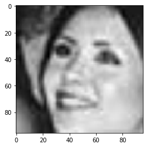

```python
plt.imshow(train_x[1000].reshape(96,96), cmap='gray')
```

Now that the train_x data is cleaned up and ready, lets take care of the labels.

Currently, the labels are 15 features, represented by x and y coordinates, giving a total of 30 data fields.

At first, I will attempt to train by concatenating all features of each image into a 30-dimensional vector of floats.

```python
# remove the 'Image' column, as that has been placed in train_x already, and we dont need it to occupy memory any longer
train_data = train_data.drop('Image', axis=1)

# ensure that 'Image' Column was removed correctly
train_data.head().T
```

|  | 0 | 1 | 2 | 3 | 4 |
| --- | --- | --- | --- | --- | --- |
| left_eye_center_x | 66.033564 | 64.332936 | 65.057053 | 65.225739 | 66.725301 |
| left_eye_center_y | 39.002274 | 34.970077 | 34.909642 | 37.261774 | 39.621261 |
| right_eye_center_x | 30.227008 | 29.949277 | 30.903789 | 32.023096 | 32.244810 |
| right_eye_center_y | 36.421678 | 33.448715 | 34.909642 | 37.261774 | 38.042032 |
| left_eye_inner_corner_x | 59.582075 | 58.856170 | 59.412000 | 60.003339 | 58.565890 |
| left_eye_inner_corner_y | 39.647423 | 35.274349 | 36.320968 | 39.127179 | 39.621261 |
| left_eye_outer_corner_x | 73.130346 | 70.722723 | 70.984421 | 72.314713 | 72.515926 |
| left_eye_outer_corner_y | 39.969997 | 36.187166 | 36.320968 | 38.380967 | 39.884466 |
| right_eye_inner_corner_x | 36.356571 | 36.034723 | 37.678105 | 37.618643 | 36.982380 |
| right_eye_inner_corner_y | 37.389402 | 34.361532 | 36.320968 | 38.754115 | 39.094852 |
| right_eye_outer_corner_x | 23.452872 | 24.472511 | 24.976421 | 25.307270 | 22.506110 |
| right_eye_outer_corner_y | 37.389402 | 33.144443 | 36.603221 | 38.007903 | 38.305237 |
| left_eyebrow_inner_end_x | 56.953263 | 53.987404 | 55.742526 | 56.433809 | 57.249571 |
| left_eyebrow_inner_end_y | 29.033648 | 28.275949 | 27.570947 | 30.929864 | 30.672177 |
| left_eyebrow_outer_end_x | 80.227128 | 78.634213 | 78.887368 | 77.910261 | 77.762945 |
| left_eyebrow_outer_end_y | 32.228138 | 30.405923 | 32.651621 | 31.665725 | 31.737247 |
| right_eyebrow_inner_end_x | 40.227609 | 42.728851 | 42.193895 | 41.671513 | 38.035436 |
| right_eyebrow_inner_end_y | 29.002322 | 26.146043 | 28.135453 | 31.049990 | 30.935382 |
| right_eyebrow_outer_end_x | 16.356379 | 16.865362 | 16.791158 | 20.458017 | 15.925870 |
| right_eyebrow_outer_end_y | 29.647471 | 27.058860 | 32.087116 | 29.909343 | 30.672177 |
| nose_tip_x | 44.420571 | 48.206298 | 47.557263 | 51.885078 | 43.299534 |
| nose_tip_y | 57.066803 | 55.660936 | 53.538947 | 54.166539 | 64.889521 |
| mouth_left_corner_x | 61.195308 | 56.421447 | 60.822947 | 65.598887 | 60.671411 |
| mouth_left_corner_y | 79.970165 | 76.352000 | 73.014316 | 72.703722 | 77.523239 |
| mouth_right_corner_x | 28.614496 | 35.122383 | 33.726316 | 37.245496 | 31.191755 |
| mouth_right_corner_y | 77.388992 | 76.047660 | 72.732000 | 74.195478 | 76.997301 |
| mouth_center_top_lip_x | 43.312602 | 46.684596 | 47.274947 | 50.303165 | 44.962748 |
| mouth_center_top_lip_y | 72.935459 | 70.266553 | 70.191789 | 70.091687 | 73.707387 |
| mouth_center_bottom_lip_x | 43.130707 | 45.467915 | 47.274947 | 51.561183 | 44.227141 |
| mouth_center_bottom_lip_y | 84.485774 | 85.480170 | 78.659368 | 78.268383 | 86.871166 |

Now, place all 7049 30-dim vector of labels into a numpy array

```python
train_y = []
for img_idx in range(0,7049):
  y = train_data.iloc[img_idx, :]
  train_y.append(y)

train_y = np.array(train_y, dtype='float32')
```

Randomize the training data:

```python
n = train_x.shape[0]

rand_indices = np.random.permutation(n)
train_indices = rand_indices[0:n]
```

```python
train_x = train_x[train_indices]
train_y = train_y[train_indices]
```

### 1.3.4 Place training data into a generator (omitted)

```python
# from keras.preprocessing.image import ImageDataGenerator

# image_generator = ImageDataGenerator(
#                                     # horizontal_flip = True,
#                                     # rotation_range = 10,
#                                     # height_shift_range = 0.05,
#                                     #  width_shift_range = 0.05
# )

# image_generator.fit(train_x)
```

## 1.4 Test Data

### 1.4.1 Prepare test data

Just like I placed the "Image" column values into a numpy array of arrays in the training data, I'll do the same with the test data.

### 1.4.2 Look at the test data

How many data points are there in the test set? How is the test data formatted?

```python
print(test_data.shape)
test_data.head()
```

```
(1783, 2)
```

|  | ImageId | Image |
| --- | --- | --- |
| 0 | 1 | 182 183 182 182 180 180 176 169 156 137 124 10... |
| 1 | 2 | 76 87 81 72 65 59 64 76 69 42 31 38 49 58 58 4... |
| 2 | 3 | 177 176 174 170 169 169 168 166 166 166 161 14... |
| 3 | 4 | 176 174 174 175 174 174 176 176 175 171 165 15... |
| 4 | 5 | 50 47 44 101 144 149 120 58 48 42 35 35 37 39 ... |

```python
test_x = []

for img_idx in range(0, 1783):
  img = test_data['Image'][img_idx].split(' ')
  img = ['0' if x == '' else x for x in img]

  test_x.append(img)
```

```python
# cast the data into a numpy array
test_x = np.array(test_x, dtype='float32')
test_x = test_x.reshape(-1, 9216)
```

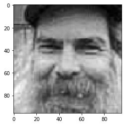

```python
# show an image to ensure reshaping and casting went well
plt.imshow(test_x[1782].reshape(96,96), cmap='gray')
```

### 1.4.3 Understand the submission format

As part of the data, I was given a sample submission. Lets explore that file.

```python
sample_submission_dir = '/content/drive/My Drive/F19/CS 583 - Deep Learning/Assignments/final-project/data/SampleSubmission.csv'
submission_data = pd.read_csv(sample_submission_dir)
```

```python
submission_data.head()
```

|  | RowId | Location |
| --- | --- | --- |
| 0 | 1 | 0 |
| 1 | 2 | 0 |
| 2 | 3 | 0 |
| 3 | 4 | 0 |
| 4 | 5 | 0 |

Looks like there is just two columns, and 27124 rows. There is only a `rowId` to identify each row.

Lets look at the fourth file we were given, and get some clues as to how this submission is wanted:

```python
lookid_data.head()
```

|  | RowId | ImageId | FeatureName | Location |
| --- | --- | --- | --- | --- |
| 0 | 1 | 1 | left_eye_center_x | NaN |
| 1 | 2 | 1 | left_eye_center_y | NaN |
| 2 | 3 | 1 | right_eye_center_x | NaN |
| 3 | 4 | 1 | right_eye_center_y | NaN |
| 4 | 5 | 1 | left_eye_inner_corner_x | NaN |

Each row in the submission file has a rowID. We can use the `lookid_data` file to find which Image and which predicted feature belong to each rowID.

## 1.5 Summary of Data Preprocessing

During this first section, I got to understand how my data is provided to me, and what are the setbacks of the data that will make training harder.

I found out that the data had lots of holes, with missing information on 4909 out of the 7049 images, almost 70% of my data points were incomplete!

I opted for a solution that will take the average of the value for that feature among all datapoints.

If I have more time, I would like to calculate the standard deviation of each feature, to see if using the mean of the feature to fill out the missing holes is actually a good estimate.

For the test data, I formatted it the same way as the training data.

# 2 The Models

Since I only have 7049 examples, I want to avoid overfitting. In this section **I will try different models**. Note that I will name these models differently, but **to run the "best" model only, you should skip the sections containing the "other" models.**

## 2.1 Training a simple FC model

```python
def build_simple_model():
  """function that defines model with 2 hidden layers, and compiles it.
  returns compiled model"""
  model = Sequential()
  model.add(Dense(128, activation='relu', input_shape=(9216,)))
  model.add(Dense(64, activation='relu'))
  model.add(Dense(30))

  model.compile(optimizer='rmsprop', loss='mse', metrics=['mae', 'mse'])
  print(model.summary())
  return model
```

```python
simple_model = build_simple_model()

simple_model_history = simple_model.fit(train_x, train_y, batch_size=32,
                           epochs=500, validation_split=0.2)
```

```
Model: "sequential_3"
_________________________________________________________________
Layer (type)                 Output Shape              Param #
=================================================================
dense_7 (Dense)              (None, 128)               1179776
_________________________________________________________________
dense_8 (Dense)              (None, 64)                8256
_________________________________________________________________
dense_9 (Dense)              (None, 30)                1950
=================================================================
Total params: 1,189,982
Trainable params: 1,189,982
Non-trainable params: 0
_________________________________________________________________
None
Train on 5639 samples, validate on 1410 samples
```

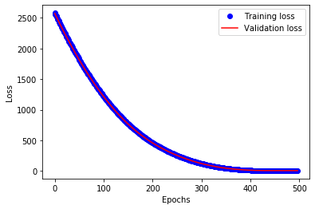

```python
import matplotlib.pyplot as plt
%matplotlib inline

loss = simple_model_history.history['loss'][3:]
val_loss = simple_model_history.history['val_loss'][3:]

epochs = range(len(loss))

plt.plot(epochs, loss, 'bo', label='Training loss')
plt.plot(epochs, val_loss, 'r', label='Validation loss')
plt.xlabel('Epochs')
plt.ylabel('Loss')
plt.legend()
plt.show()
```

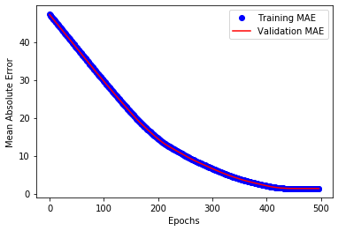

```python
mae = simple_model_history.history['mean_absolute_error'][3:]
val_mae = simple_model_history.history['val_mean_absolute_error'][3:]

epochs = range(len(mae))

plt.plot(epochs, mae, 'bo', label='Training MAE')
plt.plot(epochs, val_mae, 'r', label='Validation MAE')
plt.xlabel('Epochs')
plt.ylabel('Mean Absolute Error')
plt.legend()
plt.show()
```

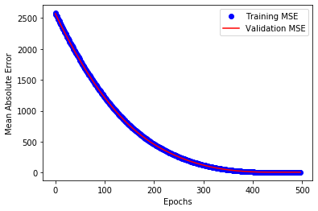

```python
mse = simple_model_history.history['mean_squared_error'][3:]
val_mse = simple_model_history.history['val_mean_squared_error'][3:]

epochs = range(len(mae))

plt.plot(epochs, mse, 'bo', label='Training MSE')
plt.plot(epochs, val_mse, 'r', label='Validation MSE')
plt.xlabel('Epochs')
plt.ylabel('Mean Absolute Error')
plt.legend()
plt.show()
```

**Performance of Simple Model**

The simple model does not overfit on the validation data even after training reaches a plateau. I will assume that plateau is just due to reaching the learning capacity of this simple model.

I will confirm my suspicion by increasing the model capacity, and seeing if (with proper regularization) I can reach lower errors.

### 2.1.2 Testing Simple model

Now its time to prepare my first submission to the competition, and see how far down the leaderboard I get.

[figure not shown]

### 2.1.3 Predict on the test data

```python
pred = simple_model.predict(test_x)
```

### 2.1.4 Create submission file

```python
lookid_list = list(lookid_data['FeatureName'])
imageID = list(lookid_data['ImageId']-1)
pre_list = list(pred)
```

```python
rowid = list(lookid_data['RowId'])
```

```python
feature = []

for f in lookid_list:
    feature.append(lookid_list.index(f))
```

```python
preded = []

for x,y in zip(imageID, feature):
    preded.append(pre_list[x][y])
```

```python
rowid = pd.Series(rowid, name = 'RowId')
loc = pd.Series(preded, name='Location')
```

```python
submission = pd.concat([rowid, loc], axis=1)
```

```python
submission.to_csv('submission_simple_model.csv', index=False)
```

### 2.1.5 Results of Simple Model

The simple 2 layer fully connected network achieves a Root Mean Squared Error of 3.96 on the competition. This is ranking 141 out of 175 competitors.

I consider this a bad result, and judging by the plots of training and validation loss, the model does not overfit at all during training, even without any regularization.

My next step will be to increase the complexity of the Fully Connected model, and regularize when appropriate.

## 2.2 Training a Medium Complexity Model

This time around, I'll be adding more layers to the FC model, and I will add regularization as I see appropriate from observing the behavior of the model during training.

```python
def build_mid_model():
    """function that defines model with 6 hidden layers, and compiles it.
    returns compiled model"""
    model = Sequential()
    model.add(Dense(256, activation='relu', input_shape=(9216,)))
    model.add(Dropout(0.2))
    model.add(Dense(256, activation='relu'))
    model.add(Dropout(0.2))
    model.add(Dense(128, activation='relu'))
    model.add(Dense(128, activation='relu'))
    model.add(Dense(64, activation='relu'))
    model.add(Dense(64, activation='relu'))
    model.add(Dense(30))

    model.compile(optimizer='rmsprop', loss='mse', metrics=['mae'])
    print(model.summary())
    return model
```

```python
mid_model = build_mid_model()

mid_model_history = mid_model.fit(train_x, train_y, batch_size=32,
                           epochs=300, validation_split=0.2)
```

```
WARNING:tensorflow:From /usr/local/lib/python3.6/dist-packages/keras/backend/tensorflow_backend.py:148: The name tf.placeholder_with_default is deprecated. Please use tf.compat.v1.placeholder_with_default instead.

WARNING:tensorflow:From /usr/local/lib/python3.6/dist-packages/keras/backend/tensorflow_backend.py:3733: calling dropout (from tensorflow.python.ops.nn_ops) with keep_prob is deprecated and will be removed in a future version.
Instructions for updating:
Please use `rate` instead of `keep_prob`. Rate should be set to `rate = 1 - keep_prob`.
Model: "sequential_5"
_________________________________________________________________
Layer (type)                 Output Shape              Param #
=================================================================
dense_17 (Dense)             (None, 256)               2359552
_________________________________________________________________
dropout_1 (Dropout)          (None, 256)               0
_________________________________________________________________
dense_18 (Dense)             (None, 256)               65792
_________________________________________________________________
dropout_2 (Dropout)          (None, 256)               0
_________________________________________________________________
dense_19 (Dense)             (None, 128)               32896
_________________________________________________________________
dense_20 (Dense)             (None, 128)               16512
_________________________________________________________________
dense_21 (Dense)             (None, 64)                8256
_________________________________________________________________
dense_22 (Dense)             (None, 64)                4160
_________________________________________________________________
dense_23 (Dense)             (None, 30)                1950
=================================================================
Total params: 2,489,118
Trainable params: 2,489,118
Non-trainable params: 0
_________________________________________________________________
None
Train on 5639 samples, validate on 1410 samples
```

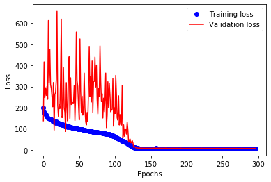

```python
loss = mid_model_history.history['loss'][3:]
val_loss = mid_model_history.history['val_loss'][3:]

epochs = range(len(loss))

plt.plot(epochs, loss, 'bo', label='Training loss')
plt.plot(epochs, val_loss, 'r', label='Validation loss')
plt.xlabel('Epochs')
plt.ylabel('Loss')
plt.legend()
plt.show()
```

```python
mae = mid_model_history.history['mean_absolute_error'][3:]
val_mae = mid_model_history.history['val_mean_absolute_error'][3:]

epochs = range(len(mae))

plt.plot(epochs, mae, 'bo', label='Training MAE')
plt.plot(epochs, val_mae, 'r', label='Validation MAE')
plt.xlabel('Epochs')
plt.ylabel('Mean Absolute Error')
plt.legend()
plt.show()
```

[output not shown]

[figure not shown]

```python
mse = mid_model_history.history['mean_squared_error'][3:]
val_mse = mid_model_history.history['val_mean_squared_error'][3:]

epochs = range(len(mae))

plt.plot(epochs, mse, 'bo', label='Training MSE')
plt.plot(epochs, val_mse, 'r', label='Validation MSE')
plt.xlabel('Epochs')
plt.ylabel('Mean Absolute Error')
plt.legend()
plt.show()
```

### 2.2.2 Testing Medium Complexity FC model

Now its time to prepare my first second submission to the competition, and see if there is any improvement from the Simple Model.

[figure not shown]

### 2.2.3 Predict on the test data

```python
pred = mid_model.predict(test_x)
```

### 2.2.4 Create submission file

```python
lookid_list = list(lookid_data['FeatureName'])
imageID = list(lookid_data['ImageId']-1)
pre_list = list(pred)
```

```python
rowid = list(lookid_data['RowId'])
```

```python
feature = []

for f in lookid_list:
    feature.append(lookid_list.index(f))
```

```python
preded = []

for x,y in zip(imageID, feature):
    preded.append(pre_list[x][y])
```

```python
rowid = pd.Series(rowid, name = 'RowId')
loc = pd.Series(preded, name='Location')
```

```python
submission = pd.concat([rowid, loc], axis=1)
```

```python
submission.to_csv('submission_mid_model.csv', index=False)
```

### 2.2.5 Results of Medium FC Model

The medium complexity 6 layer fully connected network achieves a Root Mean Squared Error of 3.65 on the competition. This is ranking 99 out of 175 competitors.

This is definitely a better result than the simple model, which ranked 141/175 in the competition. Judging by the plots of training and validation loss, the model does not overfit at all during training, especially with the little regularization.

My next step will be to increase the complexity of the Fully Connected model even more, and regularize when appropriate.

## 2.3 Training a Large FC Model

This time around, I'll be adding even more layers to the FC model, and I will add regularization as I see appropriate from observing the behavior of the model during training.

If this does not improve my performance significantly, I will attempt a convolutional neural network.

```python
def build_large_model():
    """function that defines model with 12 hidden layers, and compiles it.
    returns compiled model"""
    model = Sequential()
    model.add(Dense(256, activation='relu', input_shape=(9216,))) #1
    model.add(Dropout(0.5))
    model.add(Dense(256, activation='relu')) #2
    model.add(Dropout(0.2))
    model.add(Dense(256, activation='relu')) #3
    model.add(Dropout(0.2))
    model.add(Dense(256, activation='relu')) #4
    model.add(Dropout(0.2))
    model.add(Dense(256, activation='relu')) #4
    model.add(Dropout(0.2))
    model.add(Dense(256, activation='relu')) #5
    model.add(Dropout(0.2))
    model.add(Dense(256, activation='relu')) #3
    model.add(Dropout(0.2))
    model.add(Dense(256, activation='relu')) #4
    model.add(Dropout(0.2))
    model.add(Dense(256, activation='relu')) #4
    model.add(Dropout(0.2))
    model.add(Dense(256, activation='relu')) #5
    model.add(Dropout(0.2))
    model.add(Dense(256, activation='relu')) #3
    model.add(Dropout(0.2))
    model.add(Dense(256, activation='relu')) #4
    model.add(Dropout(0.2))
    model.add(Dense(256, activation='relu')) #4
    model.add(Dropout(0.2))
    model.add(Dense(256, activation='relu')) #5
    model.add(Dropout(0.2))
    model.add(Dense(128, activation='relu')) #8
    model.add(Dense(64, activation='relu')) #12
    model.add(Dense(30))

    rmsprop = optimizers.RMSprop(lr=0.001)
    model.compile(optimizer=rmsprop, loss='mse', metrics=['mae'])
    print(model.summary())
    return model
```

```python
large_model = build_large_model()

large_model_history = large_model.fit(train_x, train_y, batch_size=32,
                           epochs=300, validation_split=0.2)
```

```
Model: "sequential_13"
_________________________________________________________________
Layer (type)                 Output Shape              Param #
=================================================================
dense_115 (Dense)            (None, 256)               2359552
_________________________________________________________________
dropout_37 (Dropout)         (None, 256)               0
_________________________________________________________________
dense_116 (Dense)            (None, 256)               65792
_________________________________________________________________
dropout_38 (Dropout)         (None, 256)               0
_________________________________________________________________
dense_117 (Dense)            (None, 256)               65792
_________________________________________________________________
dropout_39 (Dropout)         (None, 256)               0
_________________________________________________________________
dense_118 (Dense)            (None, 256)               65792
_________________________________________________________________
dropout_40 (Dropout)         (None, 256)               0
_________________________________________________________________
dense_119 (Dense)            (None, 256)               65792
_________________________________________________________________
dropout_41 (Dropout)         (None, 256)               0
_________________________________________________________________
dense_120 (Dense)            (None, 256)               65792
_________________________________________________________________
dropout_42 (Dropout)         (None, 256)               0
_________________________________________________________________
dense_121 (Dense)            (None, 256)               65792
_________________________________________________________________
dropout_43 (Dropout)         (None, 256)               0
_________________________________________________________________
dense_122 (Dense)            (None, 256)               65792
_________________________________________________________________
dropout_44 (Dropout)         (None, 256)               0
_________________________________________________________________
dense_123 (Dense)            (None, 256)               65792
_________________________________________________________________
dropout_45 (Dropout)         (None, 256)               0
_________________________________________________________________
```

[output cut: 17 more lines]

```
_________________________________________________________________
dropout_50 (Dropout)         (None, 256)               0
_________________________________________________________________
dense_129 (Dense)            (None, 128)               32896
_________________________________________________________________
dense_130 (Dense)            (None, 64)                8256
_________________________________________________________________
dense_131 (Dense)            (None, 30)                1950
=================================================================
Total params: 3,257,950
Trainable params: 3,257,950
Non-trainable params: 0
_________________________________________________________________
None
Train on 5639 samples, validate on 1410 samples
```

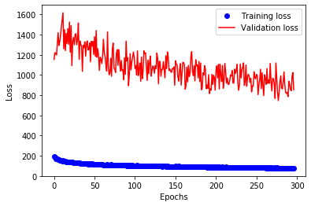

```python
loss = large_model_history.history['loss'][3:]
val_loss = large_model_history.history['val_loss'][3:]

epochs = range(len(loss))

plt.plot(epochs, loss, 'bo', label='Training loss')
plt.plot(epochs, val_loss, 'r', label='Validation loss')
plt.xlabel('Epochs')
plt.ylabel('Loss')
plt.legend()
plt.show()
```

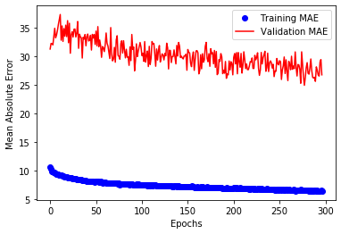

```python
mae = large_model_history.history['mean_absolute_error'][3:]
val_mae = large_model_history.history['val_mean_absolute_error'][3:]

epochs = range(len(mae))

plt.plot(epochs, mae, 'bo', label='Training MAE')
plt.plot(epochs, val_mae, 'r', label='Validation MAE')
plt.xlabel('Epochs')
plt.ylabel('Mean Absolute Error')
plt.legend()
plt.show()
```

I attemped several different "deeper" FC models. Some with a large 512 node layer at the beginning, and some with at most 128 node layers. I tried gradually decreasing the size of the layers, or keeping them the same, etc.

```python
submission.to_csv('submission_mid_model.csv', index=False)
```

## 2.4 Training a Convolutional Neural Network

After the big failure of the "deeper" fully connected layer for this problem, I felt like I should do some reading. I found a [research paper](https://arxiv.org/pdf/1710.00977.pdf) in arxiv.org that helped me get an idea of a possible good starting point for a CNN.

Let's see how the CNN does!

```python
train_x_cnn = train_x.reshape(7049,96,96,1)
```

```python
def build_cnn_model():
    """function that defines convolutional neural network model, and compiles it.
    returns compiled model"""
    model = Sequential()

    model.add(Conv2D(32, (4,4), input_shape=(96,96,1)))
    model.add(BatchNormalization())
    model.add(Activation('relu'))

    model.add(MaxPooling2D(pool_size=(2,2)))

    model.add(Conv2D(64, (3,3)))
    model.add(BatchNormalization())
    model.add(Activation('relu'))

    model.add(MaxPooling2D(pool_size=(2,2)))

    model.add(Conv2D(128, (2,2)))
    model.add(BatchNormalization())
    model.add(Activation('relu'))

    model.add(MaxPooling2D(pool_size=(2,2)))

    model.add(Conv2D(128, (1,1)))
    model.add(BatchNormalization())
    model.add(Activation('relu'))

    model.add(MaxPooling2D(pool_size=(2,2)))

    model.add(Flatten())
    model.add(Dropout(0.5))
    model.add(Dense(256, activation='relu'))
    model.add(Dropout(0.1))
    model.add(Dense(128, activation='relu'))
    model.add(Dense(30))

    adamopt = optimizers.Adam()

    model.compile(optimizer=adamopt, loss='mse', metrics=['mae'])
    print(model.summary())
    return model
```

```python
cnn_model = build_cnn_model()

lr_reducer = ReduceLROnPlateau(monitor='val_loss', factor=0.1,
                               cooldown=0, patience=6, min_lr=0.5e-6, verbose=1)

cnn_model_history = cnn_model.fit(train_x_cnn, train_y, batch_size=64,
                           epochs=50, validation_split=0.2,
                           callbacks=[lr_reducer])
```

```
Model: "sequential_29"
_________________________________________________________________
Layer (type)                 Output Shape              Param #
=================================================================
conv2d_57 (Conv2D)           (None, 93, 93, 32)        544
_________________________________________________________________
batch_normalization_56 (Batc (None, 93, 93, 32)        128
_________________________________________________________________
activation_56 (Activation)   (None, 93, 93, 32)        0
_________________________________________________________________
max_pooling2d_56 (MaxPooling (None, 46, 46, 32)        0
_________________________________________________________________
conv2d_58 (Conv2D)           (None, 44, 44, 64)        18496
_________________________________________________________________
batch_normalization_57 (Batc (None, 44, 44, 64)        256
_________________________________________________________________
activation_57 (Activation)   (None, 44, 44, 64)        0
_________________________________________________________________
max_pooling2d_57 (MaxPooling (None, 22, 22, 64)        0
_________________________________________________________________
conv2d_59 (Conv2D)           (None, 21, 21, 128)       32896
_________________________________________________________________
batch_normalization_58 (Batc (None, 21, 21, 128)       512
_________________________________________________________________
activation_58 (Activation)   (None, 21, 21, 128)       0
_________________________________________________________________
max_pooling2d_58 (MaxPooling (None, 10, 10, 128)       0
_________________________________________________________________
conv2d_60 (Conv2D)           (None, 10, 10, 128)       16512
_________________________________________________________________
batch_normalization_59 (Batc (None, 10, 10, 128)       512
_________________________________________________________________
activation_59 (Activation)   (None, 10, 10, 128)       0
_________________________________________________________________
max_pooling2d_59 (MaxPooling (None, 5, 5, 128)         0
_________________________________________________________________
flatten_15 (Flatten)         (None, 3200)              0
_________________________________________________________________
dropout_79 (Dropout)         (None, 3200)              0
_________________________________________________________________
dense_174 (Dense)            (None, 256)               819456
_________________________________________________________________
dropout_80 (Dropout)         (None, 256)               0
_________________________________________________________________
dense_175 (Dense)            (None, 128)               32896
_________________________________________________________________
dense_176 (Dense)            (None, 30)                3870
=================================================================
Total params: 926,078
Trainable params: 925,374
Non-trainable params: 704
_________________________________________________________________
None
Train on 5639 samples, validate on 1410 samples

Epoch 00018: ReduceLROnPlateau reducing learning rate to 0.00010000000474974513.

Epoch 00028: ReduceLROnPlateau reducing learning rate to 1.0000000474974514e-05.

Epoch 00034: ReduceLROnPlateau reducing learning rate to 1.0000000656873453e-06.

Epoch 00040: ReduceLROnPlateau reducing learning rate to 5e-07.
```

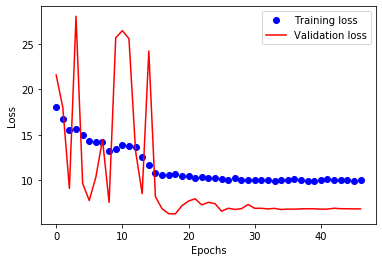

```python
loss = cnn_model_history.history['loss'][3:]
val_loss = cnn_model_history.history['val_loss'][3:]

epochs = range(len(loss))

plt.plot(epochs, loss, 'bo', label='Training loss')
plt.plot(epochs, val_loss, 'r', label='Validation loss')
plt.xlabel('Epochs')
plt.ylabel('Loss')
plt.legend()
plt.show()
```

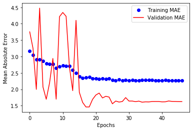

```python
mae = cnn_model_history.history['mean_absolute_error'][3:]
val_mae = cnn_model_history.history['val_mean_absolute_error'][3:]

epochs = range(len(mae))

plt.plot(epochs, mae, 'bo', label='Training MAE')
plt.plot(epochs, val_mae, 'r', label='Validation MAE')
plt.xlabel('Epochs')
plt.ylabel('Mean Absolute Error')
plt.legend()
plt.show()
```

### 2.2.2 Testing ConvNet model

Now its time to prepare my third submission to the competition, and see if there is any improvement from the Fully Connected model.

[figure not shown]

### 2.2.3 Predict on the test data

```python
test_x_cnn = test_x.reshape(1783, 96, 96, 1)
```

```python
pred = cnn_model.predict(test_x_cnn)
```

### 2.2.4 Create submission file

```python
lookid_list = list(lookid_data['FeatureName'])
imageID = list(lookid_data['ImageId']-1)
pre_list = list(pred)
```

```python
rowid = list(lookid_data['RowId'])
```

```python
feature = []

for f in lookid_list:
    feature.append(lookid_list.index(f))
```

```python
preded = []

for x,y in zip(imageID, feature):
    preded.append(pre_list[x][y])
```

```python
rowid = pd.Series(rowid, name = 'RowId')
loc = pd.Series(preded, name='Location')
```

```python
submission = pd.concat([rowid, loc], axis=1)
```

```python
submission.to_csv('submission_cnn_model.csv', index=False)
```

### 2.2.5 Results of First CNN Model

This convolutional neural network achieves a RMSE of 3.35 on the competition, which is ranking 80/175. This is a nice improvement from the 6 layer FC which had achieved ranking 99/175.

Even though this CNN is definitely better than the FC model, I expected a much better result. For some reason the validation loss (RMSE_Val) is much lower (better) than the training loss, but my competition score agrees more with the training loss.

I also had to change the optimizer, because RMSprop was oscilating too much.

My next step will be to continue to explore CNN designs, and optimizers.

## 2.5 Training an improved CNN

The previous CNN did better than the FC networks. Now its time to try adding some model complexity so we can drive the training loss down.

```python
train_x_cnn = train_x.reshape(7049,96,96,1)
```

```python
def build_cnn2_model():
    """function that defines convolutional neural network model, and compiles it.
    returns compiled model"""
    model = Sequential()

    model.add(Conv2D(32, (4,4), input_shape=(96,96,1)))
    model.add(BatchNormalization())
    model.add(Activation('relu'))

    model.add(MaxPooling2D(pool_size=(2,2)))

    model.add(Conv2D(64, (3,3)))
    model.add(BatchNormalization())
    model.add(Activation('relu'))

    model.add(MaxPooling2D(pool_size=(2,2)))

    model.add(Conv2D(64, (3,3)))
    model.add(BatchNormalization())
    model.add(Activation('relu'))

    model.add(MaxPooling2D(pool_size=(2,2)))

    model.add(Conv2D(128, (2,2)))
    model.add(BatchNormalization())
    model.add(Activation('relu'))

    model.add(MaxPooling2D(pool_size=(2,2)))

    model.add(Conv2D(256, (1,1)))
    model.add(BatchNormalization())
    model.add(Activation('relu'))

    model.add(MaxPooling2D(pool_size=(2,2)))

    model.add(Flatten())
    model.add(Dropout(0.5))
    model.add(Dense(256, activation='relu'))

    model.add(Dense(128, activation='relu'))

    model.add(Dense(30))

    adamopt = optimizers.Adam()

    model.compile(optimizer=adamopt, loss='mse', metrics=['mae'])
    print(model.summary())
    return model
```

```python
cnn2_model = build_cnn2_model()

lr_reducer = ReduceLROnPlateau(monitor='val_loss', factor=0.1,
                               cooldown=0, patience=9, min_lr=0.5e-6, verbose=1)

cnn2_model_history = cnn2_model.fit(train_x_cnn, train_y, batch_size=64,
                           epochs=70, validation_split=0.2,
                           callbacks=[lr_reducer])
```

```
Model: "sequential_45"
_________________________________________________________________
Layer (type)                 Output Shape              Param #
=================================================================
conv2d_143 (Conv2D)          (None, 93, 93, 32)        544
_________________________________________________________________
batch_normalization_142 (Bat (None, 93, 93, 32)        128
_________________________________________________________________
activation_142 (Activation)  (None, 93, 93, 32)        0
_________________________________________________________________
max_pooling2d_122 (MaxPoolin (None, 46, 46, 32)        0
_________________________________________________________________
conv2d_144 (Conv2D)          (None, 44, 44, 64)        18496
_________________________________________________________________
batch_normalization_143 (Bat (None, 44, 44, 64)        256
_________________________________________________________________
activation_143 (Activation)  (None, 44, 44, 64)        0
_________________________________________________________________
max_pooling2d_123 (MaxPoolin (None, 22, 22, 64)        0
_________________________________________________________________
conv2d_145 (Conv2D)          (None, 20, 20, 64)        36928
_________________________________________________________________
batch_normalization_144 (Bat (None, 20, 20, 64)        256
_________________________________________________________________
activation_144 (Activation)  (None, 20, 20, 64)        0
_________________________________________________________________
max_pooling2d_124 (MaxPoolin (None, 10, 10, 64)        0
_________________________________________________________________
conv2d_146 (Conv2D)          (None, 9, 9, 128)         32896
_________________________________________________________________
batch_normalization_145 (Bat (None, 9, 9, 128)         512
_________________________________________________________________
activation_145 (Activation)  (None, 9, 9, 128)         0
_________________________________________________________________
max_pooling2d_125 (MaxPoolin (None, 4, 4, 128)         0
_________________________________________________________________
conv2d_147 (Conv2D)          (None, 4, 4, 256)         33024
_________________________________________________________________
batch_normalization_146 (Bat (None, 4, 4, 256)         1024
_________________________________________________________________
activation_146 (Activation)  (None, 4, 4, 256)         0
_________________________________________________________________
max_pooling2d_126 (MaxPoolin (None, 2, 2, 256)         0
_________________________________________________________________
flatten_31 (Flatten)         (None, 1024)              0
_________________________________________________________________
dropout_119 (Dropout)        (None, 1024)              0
_________________________________________________________________
dense_230 (Dense)            (None, 256)               262400
_________________________________________________________________
dense_231 (Dense)            (None, 128)               32896
_________________________________________________________________
dense_232 (Dense)            (None, 30)                3870
=================================================================
Total params: 423,230
Trainable params: 422,142
Non-trainable params: 1,088
_________________________________________________________________
None
Train on 5639 samples, validate on 1410 samples

Epoch 00034: ReduceLROnPlateau reducing learning rate to 0.00010000000474974513.
```

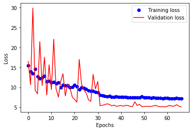

```python
loss = cnn2_model_history.history['loss'][3:]
val_loss = cnn2_model_history.history['val_loss'][3:]

epochs = range(len(loss))

plt.plot(epochs, loss, 'bo', label='Training loss')
plt.plot(epochs, val_loss, 'r', label='Validation loss')
plt.xlabel('Epochs')
plt.ylabel('Loss')
plt.legend()
plt.show()
```

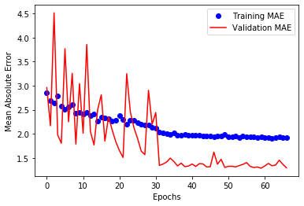

```python
mae = cnn2_model_history.history['mean_absolute_error'][3:]
val_mae = cnn2_model_history.history['val_mean_absolute_error'][3:]

epochs = range(len(mae))

plt.plot(epochs, mae, 'bo', label='Training MAE')
plt.plot(epochs, val_mae, 'r', label='Validation MAE')
plt.xlabel('Epochs')
plt.ylabel('Mean Absolute Error')
plt.legend()
plt.show()
```

### 2.2.2 Testing ConvNet model

[figure not shown]

### 2.2.3 Predict on the test data

```python
test_x_cnn = test_x.reshape(1783, 96, 96, 1)
```

```python
pred = cnn2_model.predict(test_x_cnn)
```

### 2.2.4 Create submission file

```python
lookid_list = list(lookid_data['FeatureName'])
imageID = list(lookid_data['ImageId']-1)
pre_list = list(pred)
```

```python
rowid = list(lookid_data['RowId'])
```

```python
feature = []

for f in lookid_list:
    feature.append(lookid_list.index(f))
```

```python
preded = []

for x,y in zip(imageID, feature):
    preded.append(pre_list[x][y])
```

```python
rowid = pd.Series(rowid, name = 'RowId')
loc = pd.Series(preded, name='Location')
```

```python
submission = pd.concat([rowid, loc], axis=1)
```

```python
submission.to_csv('submission_cnn3_model.csv', index=False)
```

### 2.2.5 Results of Second CNN Model

This convolutional neural network achieves a RMSE of 2.89 on the competition, which is ranking 56/175. This is a really nice improvement from the previous CNN which had achieved ranking 80/175.